# Gapminder Exploration

Kenny Chiu

2019-09-24

## Introduction

We explore the `gapminder` dataset available in the `gapminder` R package. This exploration also uses the `tidyverse` R package.

## Exercise 1: Basic `dplyr`

### 1.1

We filter the `gapminder` data to include only data from Canada, the United States, and Taiwan in the 1970’s.

```r
df = filter(gapminder,
            country == "Canada" | country == "United States" | country == "Taiwan",
            year >= 1970 & year <= 1979)
df %>%
  knitr::kable(digits = c(1, 0, 2))
```

| country | continent | year | lifeExp | pop | gdpPercap |
| --- | --- | --- | --- | --- | --- |
| Canada | Americas | 1972 | 72.9 | 22284500 | 18970.57 |
| Canada | Americas | 1977 | 74.2 | 23796400 | 22090.88 |
| Taiwan | Asia | 1972 | 69.4 | 15226039 | 4062.52 |
| Taiwan | Asia | 1977 | 70.6 | 16785196 | 5596.52 |
| United States | Americas | 1972 | 71.3 | 209896000 | 21806.04 |
| United States | Americas | 1977 | 73.4 | 220239000 | 24072.63 |

### 1.2

We extract the `country` and `gdpPercap` variables from the filtered dataset.

```r
df %>%
  select(country, gdpPercap) %>%
  knitr::kable(digits = 2)
```

| country | gdpPercap |
| --- | --- |
| Canada | 18970.57 |
| Canada | 22090.88 |
| Taiwan | 4062.52 |
| Taiwan | 5596.52 |
| United States | 21806.04 |
| United States | 24072.63 |

### 1.3

We filter the `gapminder` dataset to all entries that have experienced a drop in life expectancy.

```r
gapminder %>%
  group_by(continent, country) %>%
  mutate(lifeExp_inc = lifeExp - lag(lifeExp, order_by = year)) %>%
  filter(lifeExp_inc < 0) %>%
  DT::datatable() %>%
  DT::formatRound(columns = c("lifeExp", "gdpPercap", "lifeExp_inc"),
                  digits = 2)
```

|  | country | continent | year | lifeExp | pop | gdpPercap | lifeExp_inc |
| --- | --- | --- | --- | --- | --- | --- | --- |
| 1 | Albania | Europe | 1992 | 71.581 | 3326498 | 2497.437901 | -0.418999999999997 |
| 2 | Angola | Africa | 1987 | 39.906 | 7874230 | 2430.208311 | -0.0360000000000014 |
| 3 | Benin | Africa | 2002 | 54.406 | 7026113 | 1372.877931 | -0.371000000000002 |
| 4 | Botswana | Africa | 1992 | 62.745 | 1342614 | 7954.111645 | -0.877000000000002 |
| 5 | Botswana | Africa | 1997 | 52.556 | 1536536 | 8647.142313 | -10.189 |
| 6 | Botswana | Africa | 2002 | 46.634 | 1630347 | 11003.60508 | -5.922 |
| 7 | Bulgaria | Europe | 1977 | 70.81 | 8797022 | 7612.240438 | -0.0900000000000034 |
| 8 | Bulgaria | Europe | 1992 | 71.19 | 8658506 | 6302.623438 | -0.150000000000006 |
| 9 | Bulgaria | Europe | 1997 | 70.32 | 8066057 | 5970.38876 | -0.870000000000005 |
| 10 | Burundi | Africa | 1992 | 44.736 | 5809236 | 631.6998778 | -3.475 |

[output cut: 92 more lines]

### 1.4

We filter the `gapminder` dataset so that it shows the max GDP per capita experienced by each country.

```r
gapminder %>%
  group_by(country) %>%
  filter(gdpPercap == max(gdpPercap)) %>%
  DT::datatable() %>%
  DT::formatRound(columns = c("lifeExp", "gdpPercap"),
                  digits = c(1, 2))
```

|  | country | continent | year | lifeExp | pop | gdpPercap |
| --- | --- | --- | --- | --- | --- | --- |
| 1 | Afghanistan | Asia | 1982 | 39.854 | 12881816 | 978.0114388 |
| 2 | Albania | Europe | 2007 | 76.423 | 3600523 | 5937.029526 |
| 3 | Algeria | Africa | 2007 | 72.301 | 33333216 | 6223.367465 |
| 4 | Angola | Africa | 1967 | 35.985 | 5247469 | 5522.776375 |
| 5 | Argentina | Americas | 2007 | 75.32 | 40301927 | 12779.37964 |
| 6 | Australia | Oceania | 2007 | 81.235 | 20434176 | 34435.36744 |
| 7 | Austria | Europe | 2007 | 79.829 | 8199783 | 36126.4927 |
| 8 | Bahrain | Asia | 2007 | 75.635 | 708573 | 29796.04834 |
| 9 | Bangladesh | Asia | 2007 | 64.062 | 150448339 | 1391.253792 |
| 10 | Belgium | Europe | 2007 | 79.441 | 10392226 | 33692.60508 |

[output cut: 132 more lines]

### 1.5

We produce a scatterplot of Canada’s life expectancy vs GDP per capita.

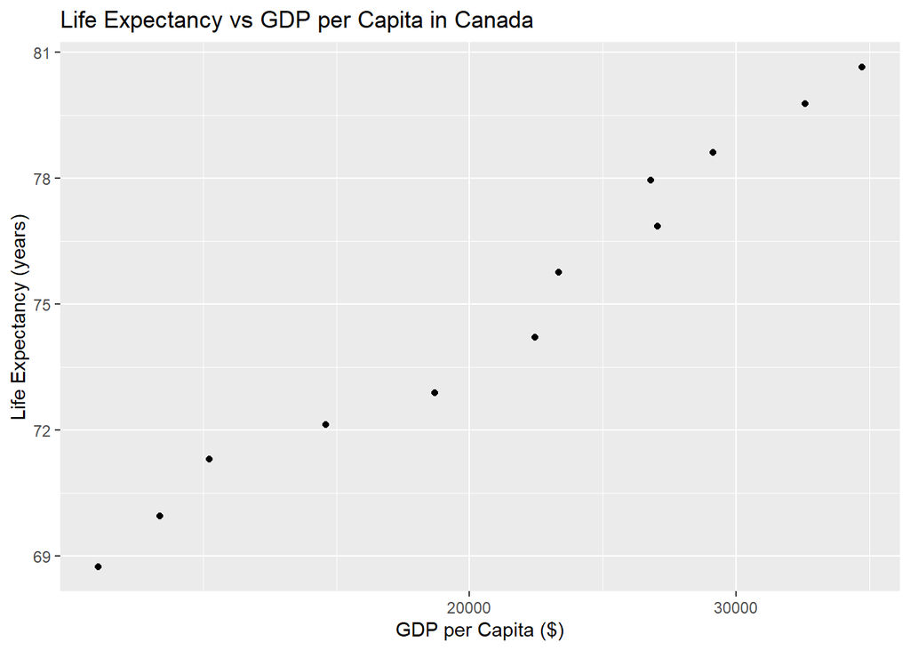

```r
gapminder %>%
  filter(country == "Canada") %>%
  ggplot(aes(gdpPercap, lifeExp)) +
  geom_point() +
  scale_x_log10() +
  labs(title = "Life Expectancy vs GDP per Capita in Canada",
       x = "GDP per Capita ($)",
       y = "Life Expectancy (years)")
```

## Exercise 2: Explore individual variables with `dplyr`

### Exploration: `continent`

We explore the `continent` variable in the `gapminder` dataset. The `continent` variable is a categorical variable that codes the continent that the observation is for. The following bar graph shows the possible values of the continent variable and the number of observations for each in the dataset.

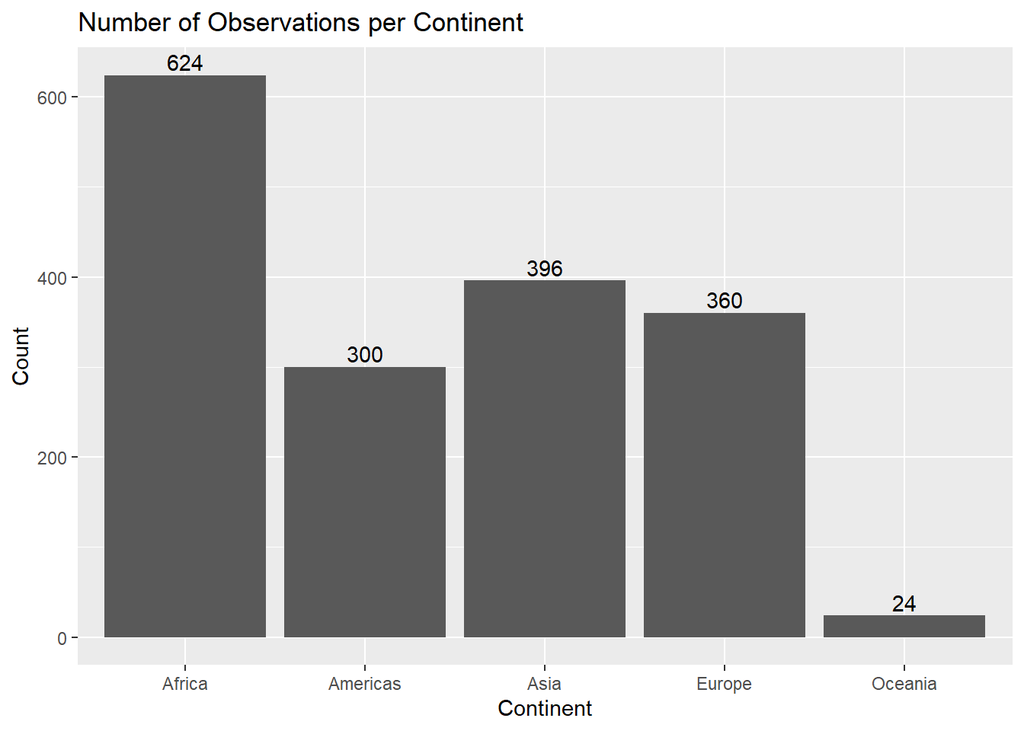

```r
gapminder %>%
  group_by(continent) %>%
  summarize(num_obs = length(continent)) %>%
  ggplot(aes(continent, num_obs)) +
  geom_bar(stat = "identity") +
  geom_text(aes(label = num_obs), vjust = -0.3) +
  labs(title = "Number of Observations per Continent",
       x = "Continent",
       y = "Count")
```

We see that Africa has a large number of observations (624) whereas Oceania only has a few (24). The difference between number of observations available for each continent can be explained by the following plot which shows the number of distinct countries in each continent.

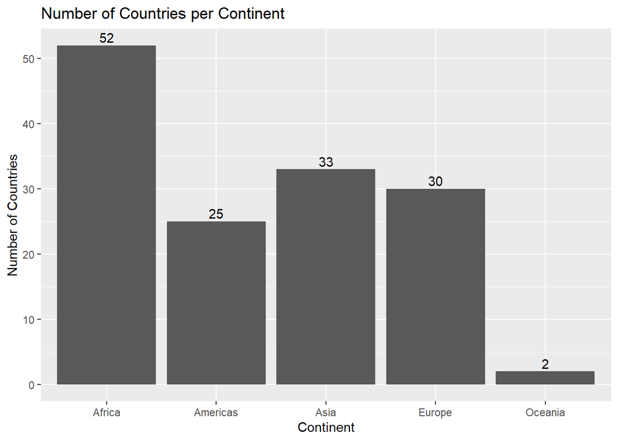

```r
gapminder %>%
  select(continent, country) %>%
  distinct() %>%
  group_by(continent) %>%
  summarize(num_obs = length(continent)) %>%
  ggplot(aes(continent, num_obs)) +
  geom_bar(stat = "identity") +
  geom_text(aes(label = num_obs), vjust = -0.3) +
  labs(title = "Number of Countries per Continent",
       x = "Continent",
       y = "Number of Countries")
```

We see that there are more countries in Africa than in Oceania. This explains why the dataset would have more observations for certain continents compared to others.

### Exploration: `lifeExp`

We explore the `lifeExp` variable in the `gapminder` dataset. The `lifeExp` variable is a quantitative variable that codes the life expectancy at birth in years. The following histogram shows the distribution of `lifeExp`.

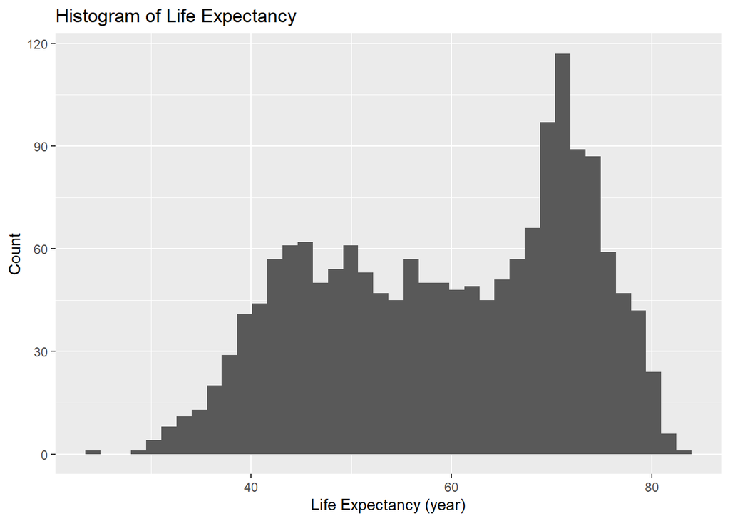

```r
gapminder %>%
  ggplot(aes(lifeExp)) +
  geom_histogram(bins = 40) +
  labs(title = "Histogram of Life Expectancy",
       x = "Life Expectancy (year)",
       y = "Count")
```

The distribution can be seen as unimodal with a long left-skew or as bimodal with a small second peak. The distribution of life expectancy peaks at around 70 to 74 years. The relevant summary statistics for `lifeExp` are shown below.

```r
# Note:
# summary() outputs a named vector which cannot be converted into a data frame directly.
# Extract names and values separately and place them into a data frame manually.

lifeExp_sum = summary(gapminder$lifeExp)[-4]  # Exclude mean
sum_names = names(lifeExp_sum)

lifeExp_sum = as.vector(lifeExp_sum) %>%
  t() %>%
  round(1) %>%
  as.data.frame()
names(lifeExp_sum) = sum_names

knitr::kable(lifeExp_sum)
```

| Min. | 1st Qu. | Median | 3rd Qu. | Max. |
| --- | --- | --- | --- | --- |
| 23.6 | 48.2 | 60.7 | 70.8 | 82.6 |

We see that the life expectancy ranges from 23.6 years to 82.6 years. The median is 60.7 years with an IQR of 22.6 years.

## Exercise 3: Explore various plot types

### Scatterplot: `pop` versus `lifeExp`

We investigate the relationship between total population and life expectancy. One may expect that both factors are indicators of a country’s social well-being, and that greater scores in either variable may indicate a better quality of life. Do countries with higher life expectancy have a greater population? We explore these claims and questions through a scatterplot created from the `gapminder` dataset. The following scatterplot plots the total population against the life expectancy for all countries in 2007.

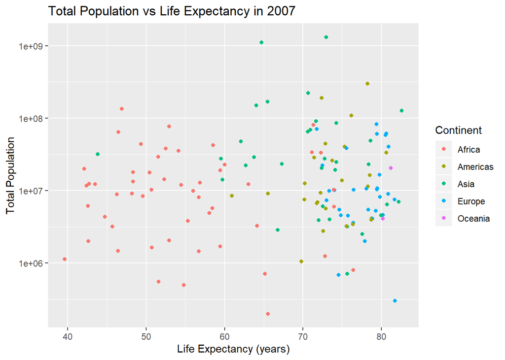

```r
gapminder %>%
  filter(year == 2007) %>%
  ggplot(aes(lifeExp, pop)) +
  geom_point(aes(color = continent)) +
  scale_y_log10() +
  labs(title = "Total Population vs Life Expectancy in 2007",
       x = "Life Expectancy (years)",
       y = "Total Population",
       color = "Continent")
```

From the scatterplot, we see that countries with higher life expectancy do not necessarily have a greater population. There are countries in Asia with relatively high life expectancy and a very large population. There are countries in Europe that have very high life expectancy and yet have a very small population. Hence there does not seem to be a strong correlation between the two factors.

However, from the plot, we do see that certain continents tend to have higher life expectancy relative to others. Many African countries have lower life expectancy, which is consistent with the fact that many of these countries are developing countries. Thus it seems that life expectancy by itself may be a decent measure of quality of life.

### Boxplot: `lifeExp`

Continuing with our investigation on measures of well-being, we compare the life expectancy of countries across different continents in the year 2000 and onwards through the following boxplot.

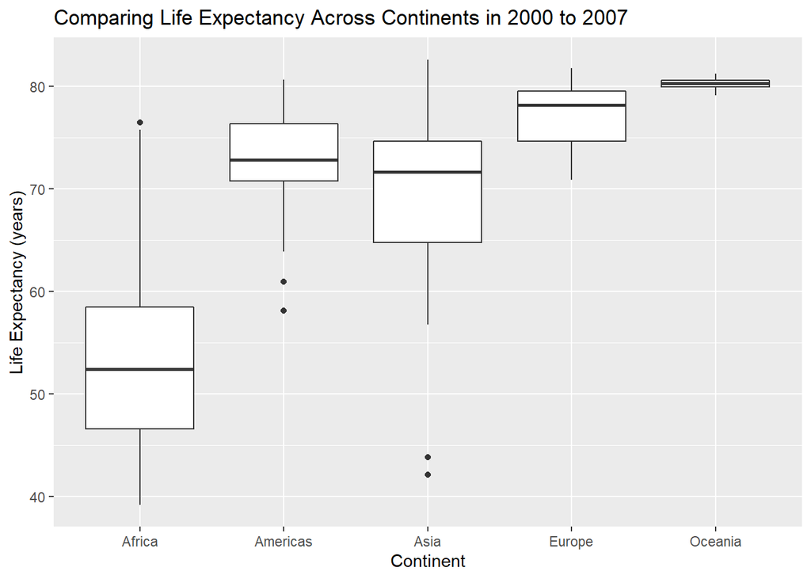

```r
gapminder %>%
  filter(year >= 2000) %>%
  ggplot(aes(continent, lifeExp)) +
  geom_boxplot() +
  labs(title = "Comparing Life Expectancy Across Continents in 2000 to 2007",
       x = "Continent",
       y = "Life Expectancy (years)")
```

The boxplot confirms that there are noticeable differences in life expectancy in different continents. As observed earlier, African countries tend to have lower life expectancy whereas the Oceania region tends to have very high life expectancy. However, there is also a non-trivial amount of within-continent variation as seen in the range of life expectancy in Asia. Thus while life expectancy generally differs across continents, whether it is a reasonable measure of quality of life is arguable and will require further investigation.

## Recycling

```r
filter(gapminder, country == c("Rwanda", "Afghanistan")) %>%
  DT::datatable() %>%
  DT::formatRound(columns = c("lifeExp", "gdpPercap"),
                  digits = c(1, 2))
```

|  | country | continent | year | lifeExp | pop | gdpPercap |
| --- | --- | --- | --- | --- | --- | --- |
| 1 | Afghanistan | Asia | 1957 | 30.332 | 9240934 | 820.8530296 |
| 2 | Afghanistan | Asia | 1967 | 34.02 | 11537966 | 836.1971382 |
| 3 | Afghanistan | Asia | 1977 | 38.438 | 14880372 | 786.11336 |
| 4 | Afghanistan | Asia | 1987 | 40.822 | 13867957 | 852.3959448 |
| 5 | Afghanistan | Asia | 1997 | 41.763 | 22227415 | 635.341351 |
| 6 | Afghanistan | Asia | 2007 | 43.828 | 31889923 | 974.5803384 |
| 7 | Rwanda | Africa | 1952 | 40 | 2534927 | 493.3238752 |
| 8 | Rwanda | Africa | 1962 | 43 | 3051242 | 597.4730727 |
| 9 | Rwanda | Africa | 1972 | 44.6 | 3992121 | 590.5806638 |
| 10 | Rwanda | Africa | 1982 | 46.218 | 5507565 | 881.5706467 |

[output cut: 2 more lines]

No, the code is not correct as only 12 rows are returned whereas 24 rows should have been returned. What the above code seems to be doing is it first finds a Rwanda observation, finds the next Afghanistan observation, and then cycles through those two steps until the end of the dataset.

The correct way to get the data is shown below.

```r
filter(gapminder, country == "Rwanda" | country == "Afghanistan") %>%
  DT::datatable() %>%
  DT::formatRound(columns = c("lifeExp", "gdpPercap"),
                  digits = c(1, 2))
```

|  | country | continent | year | lifeExp | pop | gdpPercap |
| --- | --- | --- | --- | --- | --- | --- |
| 1 | Afghanistan | Asia | 1952 | 28.801 | 8425333 | 779.4453145 |
| 2 | Afghanistan | Asia | 1957 | 30.332 | 9240934 | 820.8530296 |
| 3 | Afghanistan | Asia | 1962 | 31.997 | 10267083 | 853.10071 |
| 4 | Afghanistan | Asia | 1967 | 34.02 | 11537966 | 836.1971382 |
| 5 | Afghanistan | Asia | 1972 | 36.088 | 13079460 | 739.9811058 |
| 6 | Afghanistan | Asia | 1977 | 38.438 | 14880372 | 786.11336 |
| 7 | Afghanistan | Asia | 1982 | 39.854 | 12881816 | 978.0114388 |
| 8 | Afghanistan | Asia | 1987 | 40.822 | 13867957 | 852.3959448 |
| 9 | Afghanistan | Asia | 1992 | 41.674 | 16317921 | 649.3413952 |
| 10 | Afghanistan | Asia | 1997 | 41.763 | 22227415 | 635.341351 |

[output cut: 14 more lines]